# CITS4009 Project1

Zimin Meng 22665473

# Excecutive Summary

This project uses 1% of Australian University Enrollment data as dataset to do the exploratory data analysis which contains three main parts.

Part I includes the process of importing data, doing first step cleaning and transformation of data before analysing data and generate questions about the data.

Part II visualiazes data and explains the graph plots.

Part III is the final transformation and cleaning of the whole data set and redefine problems.

## Part I. Reading and cleaning data

tidyverse includes two functions we going to use following:

- ggplot2() : which we using for visualising data
- dplyr() : used for transforming data

`r`r # import libraries library(tidyverse)

### Read the dataset and stored into a new data frame

This project used the national enrolment dataset provided by the unit.

- head() make sure the first line of dataset automatically become the title for the data frame. After running the command, all data are stored into a new data frame called ‘df’

### Summary of dataset

Three main functions we use in here to get the summary and general information of this dataset. str(): Showing the characteristic of data and variables. And it shows the following information :

- df is a data frame which has 128967 observations and 46 variables.
- 8 variables are interger, 3 variables are number and the rest 35 variables are Factor

`r`r # data summary str(df) # looking at each variable’s type and see if it’s appropriate

[output not shown]

`r`r names(df) # variable names

```
 [1] \X\                              \Year\
 [3] \state\                          \institution_code\
 [5] \Institution\                    \Institution_Type\
 [7] \broad_course_type\              \course_type\
 [9] \gender\                         \age\
[11] \Commencing\                     \overseas\
[13] \indigenous\                     \attendance_type\
[15] \attendance_mode\                \broad_foe\
[17] \Narrow_FOE\                     \perm_home_post\
[19] \perm_home_country\              \disability\
[21] \basis_for_admission\            \special_course\
[23] \country_of_birth\               \highest_ed_attainment\
[25] \perm_home_res\                  \supp_broad_foe\
[27] \SES\                            \X_Field_of_Education\
[29] \X_Supp_field_of_education\      \atar\
[31] \course_name\                    \nesb\
[33] \campus_country\                 \noEnrol\
[35] \mceetya_regional_remote_count\  \asgs_regional_remote_count\
[37] \onshore_indicator\              \regionalremote_value\
[39] \Regional\                       \Region\
[41] \ATAR_Group\                     \Perm_Home_Postcode_Description\
[43] \Australian_Region\              \id\
[45] \updatewhen\                     \updatewho\
```

### Generating Qustions

But takking look at the data set, we need to think which variables have more realistic effect. In other words, it’s important to understand the practical significance of these variables. Normally the entering mark(which is “atar” group in this dataset), count of students for different subjects are considered by universities. Besides these, they may also interest in where are these students come from, and what’s the most popular subjects among students. Which region’s has most students? And what type of degree they doing in Australia? In this following part, we could explore all the answers for these questions.

`r`r summary(df)

```
       X               Year          state       institution_code
 Min.   :     1   Min.   :2005   NSW    :39576   Min.   :1019
 1st Qu.: 32242   1st Qu.:2008   VIC    :32580   1st Qu.:3004
 Median : 64484   Median :2012   QLD    :23902   Median :3019
 Mean   : 64484   Mean   :2011   WA     :13454   Mean   :2750
 3rd Qu.: 96726   3rd Qu.:2015   SA     : 8862   3rd Qu.:3034
 Max.   :128967   Max.   :2017   ACT    : 3978   Max.   :3045
                                 (Other): 6615
                              Institution              Institution_Type
 Monash University                  : 6653   College           :   78
 The University of Sydney           : 5964   Go8 University    :36157
 University of New South Wales      : 5548   Non-Go8 University:92732
 The University of Melbourne        : 5403
 Queensland University of Technology: 5185
 The University of Queensland       : 5137
 (Other)                            :95077
               broad_course_type                           course_type        gender
 Higher Degree Research : 7141   Bachelor's Pass                 :82588   Females:72345
 Postgraduate Coursework:28139   Master's by Coursework          :19437   Males  :56622
 Undergraduate          :93687   Doctorate by Research           : 6117
                                 Bachelor's Honours              : 4033
                                 Graduate Certificate            : 3728
                                 Postgraduate Diploma (New Study): 3165
                                 (Other)                         : 9899
       age                 Commencing        overseas               indigenous
 30 to 39:17781   Commencing    :51212   Domestic:107192   Indigenous    :  1514
 19      :13173   Non-commencing:77755   Overseas: 21775   Not Indigenous:127453
 20      :12738
 18      :11907
 21      :11387
 40 to 49: 9392
 (Other) :52589
  attendance_type     attendance_mode                   broad_foe
 Full-time:87668   External   :19662   Management And Commerc:27396
 Part-time:41299   Internal   :97082   Society And Culture   :27239
                   Multi-modal:12223   Health                :20482
                                       Education             :13085
                                       Natural And Physical S:10185
                                       Engineering And Relate: 9354
                                       (Other)               :21226
```

[output cut: 91 more lines]

```
 Median :0.00         Regional/Remote    :17310   South East Asia:  6575   85-<90 :  2658
 Mean   :0.18                                     South Asia     :  3426   80-<85 :  2593
 3rd Qu.:0.00                                     Europe         :  1540   75-<80 :  2249
 Max.   :6.00                                     Middle East    :  1460   95-<98 :  1932
 NA's   :109331                                   (Other)        :  3347   (Other):  7874
       Perm_Home_Postcode_Description             Australian_Region       id
 International        : 23157         Interstate-NSW & ACT :37678   Min.   :      49
 ATHOL QLD            :   543         Interstate-VIC       :26172   1st Qu.: 3220942
 BRANDON PARK VIC     :   477         International        :23157   Median : 6416308
 CASULA NSW           :   432         Interstate-QUEENSLAND:20596   Mean   : 6447719
 BAULKHAM HILLS NSW   :   360         Interstate-SA        : 7452   3rd Qu.: 9665626
 CONSTITUTION HILL NSW:   344         WA-Perth-North Metro.: 2857   Max.   :12896810
 (Other)              :103654         (Other)              :11055
                  updatewhen              updatewho
 07MAR2019:16:09:34.253:128967   UNIWA\\90068363:128967
```

### Subsetting: creating new data frame

Creating a new data set that only has the variables we need to use called ‘dn’.

dn includes 18 variables, and 2 of these variables are continuous and the rest 16 are categorical variables

`r`r dn <- df[,c(1:3,5:12,14:16,23,30,40:41)] summary(dn)

```
       X               Year          state
 Min.   :     1   Min.   :2005   NSW    :39576
 1st Qu.: 32242   1st Qu.:2008   VIC    :32580
 Median : 64484   Median :2012   QLD    :23902
 Mean   : 64484   Mean   :2011   WA     :13454
 3rd Qu.: 96726   3rd Qu.:2015   SA     : 8862
 Max.   :128967   Max.   :2017   ACT    : 3978
                                 (Other): 6615
                              Institution              Institution_Type
 Monash University                  : 6653   College           :   78
 The University of Sydney           : 5964   Go8 University    :36157
 University of New South Wales      : 5548   Non-Go8 University:92732
 The University of Melbourne        : 5403
 Queensland University of Technology: 5185
 The University of Queensland       : 5137
 (Other)                            :95077
               broad_course_type                           course_type        gender
 Higher Degree Research : 7141   Bachelor's Pass                 :82588   Females:72345
 Postgraduate Coursework:28139   Master's by Coursework          :19437   Males  :56622
 Undergraduate          :93687   Doctorate by Research           : 6117
                                 Bachelor's Honours              : 4033
                                 Graduate Certificate            : 3728
                                 Postgraduate Diploma (New Study): 3165
                                 (Other)                         : 9899
       age                 Commencing        overseas       attendance_type
 30 to 39:17781   Commencing    :51212   Domestic:107192   Full-time:87668
 19      :13173   Non-commencing:77755   Overseas: 21775   Part-time:41299
 20      :12738
 18      :11907
 21      :11387
 40 to 49: 9392
 (Other) :52589
    attendance_mode                   broad_foe
 External   :19662   Management And Commerc:27396
 Internal   :97082   Society And Culture   :27239
 Multi-modal:12223   Health                :20482
                     Education             :13085
                     Natural And Physical S:10185
                     Engineering And Relate: 9354
                     (Other)               :21226
                                  country_of_birth      atar                   Region
 Australia                                :82791     1    :55113   Australia      :105689
 China (excludes SARs and Taiwan Province): 6068   n/a    :31319   North Asia     :  6930
 India                                    : 3156   999    :17775   South East Asia:  6575
 Malaysia                                 : 2571   998    : 4737   South Asia     :  3426
 Hong Kong (SAR of China)                 : 1986    98    :  534   Europe         :  1540
 England                                  : 1891    95    :  523   Middle East    :  1460
 (Other)                                  :30504   (Other):18966   (Other)        :  3347
   ATAR_Group
 Unknown:108944
 90-<95 :  2717
 85-<90 :  2658
 80-<85 :  2593
 75-<80 :  2249
 95-<98 :  1932
 (Other):  7874
```

### Data Cleaning and Transformation

After generating new data frame, we need to find out whether there are missing values or unusual value. Then we decide how to deal with those values if we have.

`r`r # Firstly check where are NA’s summary(is.na(dn))

```
     X              Year           state         Institution     Institution_Type
 Mode :logical   Mode :logical   Mode :logical   Mode :logical   Mode :logical
 FALSE:128967    FALSE:128967    FALSE:128967    FALSE:128967    FALSE:128967
 broad_course_type course_type       gender           age          Commencing
 Mode :logical     Mode :logical   Mode :logical   Mode :logical   Mode :logical
 FALSE:128967      FALSE:128967    FALSE:128967    FALSE:128967    FALSE:128967
  overseas       attendance_type attendance_mode broad_foe       country_of_birth
 Mode :logical   Mode :logical   Mode :logical   Mode :logical   Mode :logical
 FALSE:128967    FALSE:128967    FALSE:128967    FALSE:128967    FALSE:128967
    atar           Region        ATAR_Group
 Mode :logical   Mode :logical   Mode :logical
 FALSE:128967    FALSE:128967    FALSE:128967
```

The result showing no NA’s with dataset. But there some unusual value we noticed with atar=999, we put these values into unknown group in order to avoid its effect on data precise.

`r`r summary(dn$atar)

```
    1    30    31    32    33    34    35    36    37    38    39    40    41    42    43
55113    11    10    11    11    14    13    10    13    17    13    28    35    30    27
   44    45    46    47    48    49    50    51    52    53    54    55    56    57    58
   25    29    46    45    51    54    62    69    71    67   109   100   113   138   133
   59    60    61    62    63    64    65    66    67    68    69    70    71    72    73
  131   195   175   214   198   215   206   244   265   293   275   312   315   309   344
   74    75    76    77    78    79    80    81    82    83    84    85    86    87    88
  343   343   366   364   399   402   430   405   497   400   442   455   450   467   443
   89    90    91    92    93    94    95    96    97    98    99   100    30    51    56
  476   468   391   485   433   511   523   516   487   534   518   117   234   104   149
   61    66    71    76    81    86    91    96   998   999   n/a
  248   282   299   375   419   367   429   406  4737 17775 31319
```

`r`r unique(dn[dn$atar == 999,]$ATAR_Group)

```
[1] Unknown
14 Levels: <50\t\t >=99 50-<55 55-<60 60-<65 65-<70 70-<75 75-<80 80-<85 85-<90 ... Unknown
```

`r`r #check when atar=999, whether it belongs to atar group atar_known <- dn[dn$ATAR_Group != ,] #create new dataframe only with known atar atar_known$atar <- as.numeric(atar_known$atar)

# Part II. Data Visualization

## Variation: Finding the behavior within the variable

Before we formally start visualizing the data, it’s important to decide whether the variables is categorical or continuous.

###### Boxplot to compares the atar for different subjects

From the graph, it’s clearly showing that ‘Engineering and Relate’ has the highest median for atar and ‘Mixed Field Programms’ has the lowest median. And also bar plot can help discover the range of the distribution and find the outliers.

`r`r atar_known <- within(atar_known, { broad_foe <- as.character(broad_foe) broad_foe[atar_known$broad_foe == ’’] <- ‘Unknown’ broad_foe <- as.factor(broad_foe) }) # Replace the blank cell(missing value) with  
ggplot(data = atar_known)+ geom_boxplot(mapping = aes(x= broad_foe, y = atar, color = broad_foe), outlier.shape = 2)+ coord_flip()

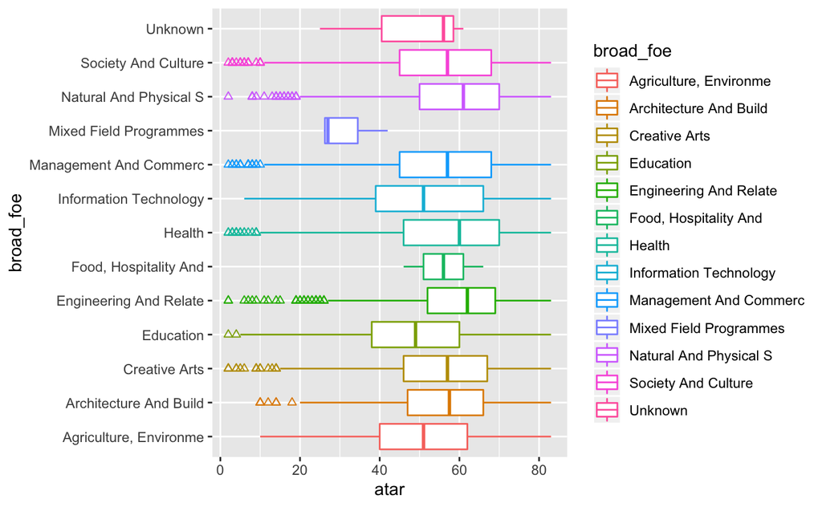

##### Bar Plot to find out which university has most enrolled student.

The graph below shows that Monash University have most students and Bond University has least enrolment students in total.

`r`r ggplot(data = atar_known)+ geom_bar(aes(x = Institution, fill = Institution), show.legend = FALSE)+ coord_flip()+ theme(axis.text.y = element_text(size = rel(0.8), color = ))

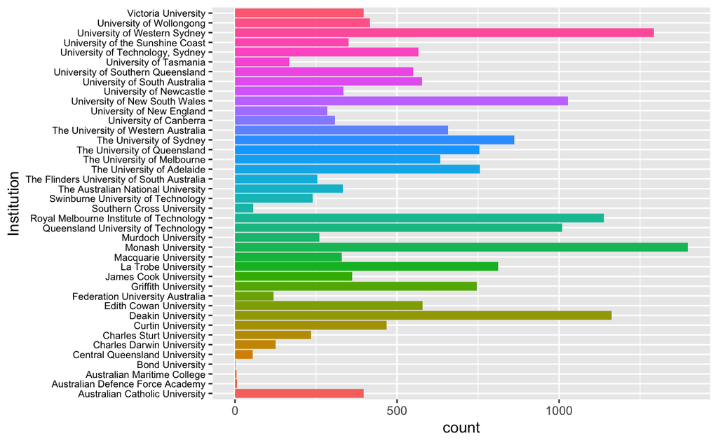

Result showing most of overseas student doing undergraduate, followed by postgraduate student. And least students doing higher degree research.

`r`r summary(dn$overseas)

```
Domestic Overseas
  107192    21775
```

`r`r overseas <- dn[dn$overseas != ,] #Select all overseas students summary(overseas$Region) #Check whether all students are from overseas, and the result showing that there is still 1 record of . Treat this as an unusual value and omit it.

```
                     Africa                   Australia Australia Onshore / Pacific
                       1046                           1                         317
                     Europe               Latin America                 Middle East
                       1385                         472                        1372
              North America                  North Asia                  South Asia
                        786                        6552                        3321
            South East Asia                     Unknown
                       6370                         153
```

`r`r overseas$Region[overseas$Region == ] <-NA new_overseas <- overseas[!is.na(overseas$Region),] ggplot(data = new_overseas)+ geom_histogram(mapping = aes(x=broad_course_type, fill = broad_course_type),stat=)

```
Ignoring unknown parameters: binwidth, bins, pad
```

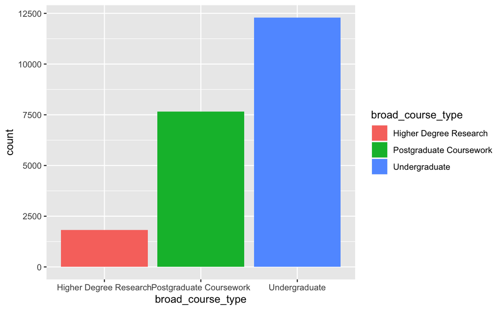

##### Geom_count and tile graph to see the distribution between two categorical variables

`r`r ggplot(data = new_overseas)+ geom_count(mapping = aes(x=broad_course_type, y = Region))

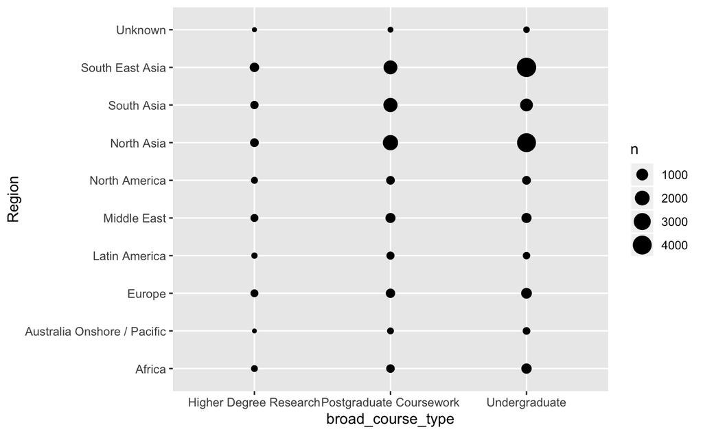

Geom_tile() Through geom_tile(), we could visulising two catergorical variable “broad_course_type” and “Region”. In realistic, this graph is another effective way to shows the amount of studnets enrols in each 3 types of course for different regions.

`r`r new_overseas %>% count(Region,broad_course_type) %>% ggplot(mapping = aes(x =broad_course_type, y = Region))+ geom_tile(mapping = aes(fill = n))+ theme(axis.text.x = element_text(size = 8))

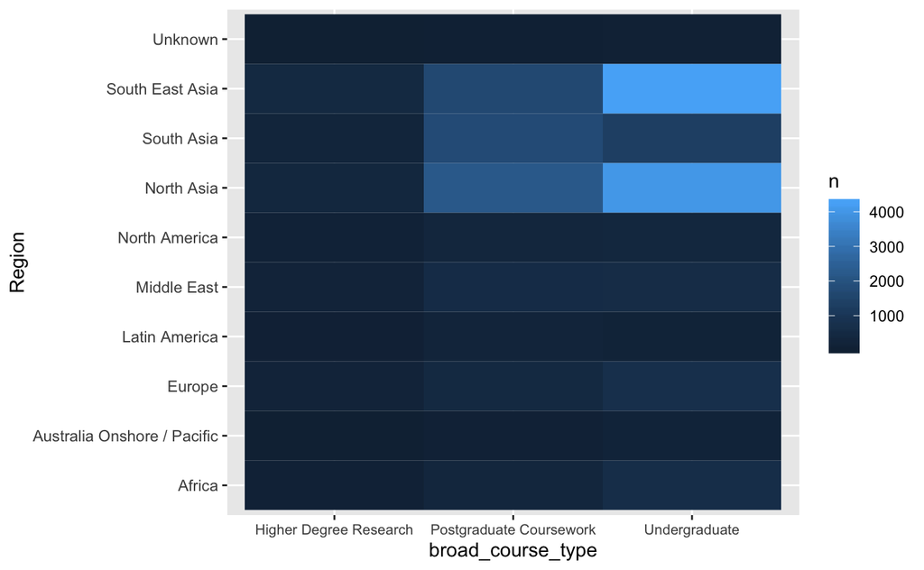

##### Polar Graph to show each year’s students distribution based on different regions

Most of enrolment student are domestic students, for overseas students, but overseas student counts for larger proportion when as year goes on.

`r`r library(ggplot2) ggplot(data = dn)+ geom_bar(mapping = aes(x = Year, fill = Region ),borders = ,alpha = 0.8,stat = , show.legend = TRUE, width = 2)+ theme(aspect.ratio = 1)+ labs(x=, y = of Student)+ coord_polar()

```
Ignoring unknown parameters: borders
```

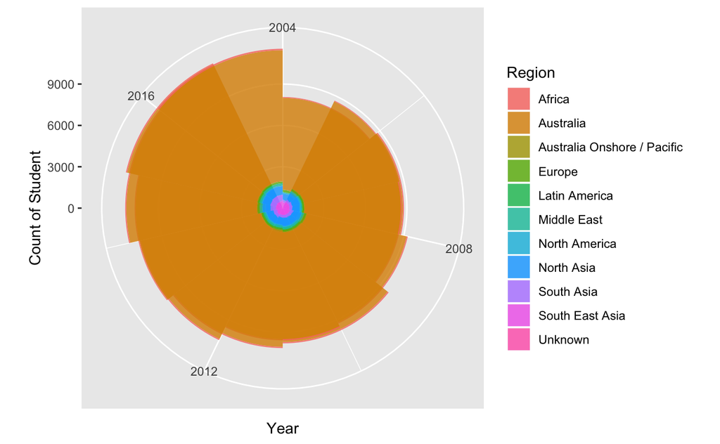

##### Side-by-Side bar chart to compares the gender distribution for different subjects

This bar chart shows both the distribution of different subjects and the count of students in each subjets. “Society and Culture” has most female students and “Management and Commerce” has most male students. Gender difference is least for “Food Hospitality And” and is most for “Health”.

`r`r ggplot(dn)+ geom_bar(dn, mapping = aes(x=broad_foe, color = gender), fill = NA, position = )+ theme(axis.text.y = element_text(size = 8), panel.background = element_rect(fill = , colour = ))+ coord_flip()

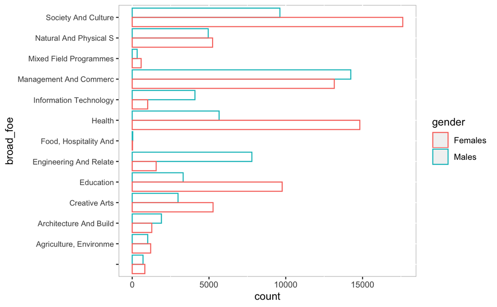

##### frequency plot for visualizing a categorical variable(State) and a continuous variable(Year).

`r`r ggplot(data = dn, mapping = aes(x = Year, color = state))+ geom_freqpoly(binwidth = 1)+ coord_cartesian(xlim = c(2004,2018))

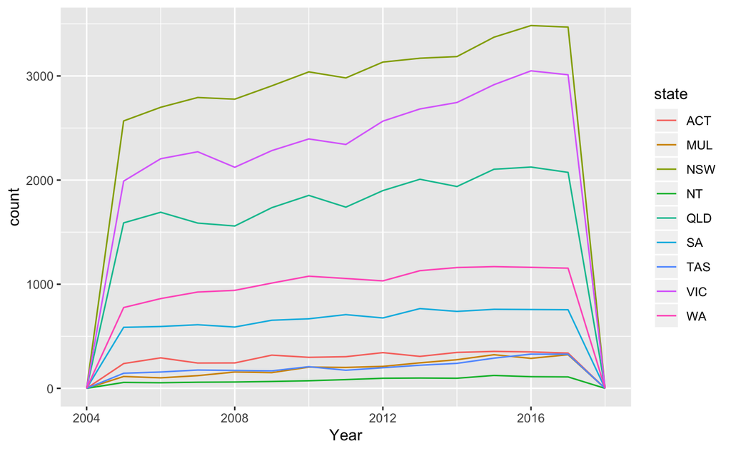

# PART III. Final Data Cleaning and Transformation

For “age”, even there is no missing value, but it composes both exact numeric age and age range. We could transforming the data

`r`r unique(df$age) #Find each level of age .

```
 [1] 19           27           17           26           40 to 49     25
 [7] 22           30 to 39     29           20           28           18
[13] 50 to 59     23           21           24           16 and under 60 and over
18 Levels: 16 and under 17 18 19 20 21 22 23 24 25 26 27 28 29 30 to 39 ... 60 and over
```

creat new coloumn “age.num” to store the age and therrfore we could easily using this new numerical variable to do future analysis.

If the age is not a exact numerci group, we using median age for that age range. i.e. age of “40 to 49” is substituted with “45”.

`r`r df <- within(df, { age.num <- as.character(age) age.num[age == ‘40 to 49’] <- 45 age.num[age == ‘30 to 39’] <- 35 age.num[age == ‘50 to 59’] <- 55 age.num[age == ‘16 and under’] <- 15 age.num[age == ‘60 and over’] <- 65 age.num <- as.numeric(age.num) })

In general, this final step of data cleaning aims to provide a tidy data for future use, even some variables are not been used during EDA.

#### Appendix of Data Set

dn : Data Set with selected variables, contains 128967 observations and 18 variables;

overseas : Data Set that only have observations for International Students, contains 21775 obs. and 18 variables.

new_overseas : new data set after figure out unusual value in overseas data set, contains 21774 obs and 18 variables.